# Diagnose Breast Cancer

Scott Ligon and Karen Tafolla

12 May 2017

## Objective

We will use mammogram screenings from 280,659 women in order to predict whether the patient is in risk of breast cancer. The screenings are from a major city from the following states: Washington, California, New Mexico, South Carolina, New Hampshire, Vermont, and Illinois.

## Information About Data Set

Each mammogram screening includes the following features:

- Menopause: To tell whether a patient has gone through menopause.
- Age Group: Patient age ranging from 35-84.
- Breast Density: Density of a patient’s breast.
- Race: Category of patients’ race.
- Hispanic: Classification if a patient is Hispanic. 0-not Hispanic 1-hispanic
- Body Mass Index: Patient’s body mass.
- Age of First Birth: Age of a patient’s first childbirth.
- Relatives with Breast Cancer: History if a patient has relatives with breast cancer.
- Breast Procedure: Records of if a patient has had a prior breast procedure.
- Last Mammogram Result: Results of the last mammogram before the index mammogram.
- Surgical Menopause: To tell if a woman has gone through a surgical menopause.
- Hormone Therapy: To tell if a woman has gone through hormone therapy.
- Invasive breast cancer: Diagnosis if invasive breast cancer has been found within a year of index screening mammogram.
- Cancer: Diagnosis of invasive or ductal carcinoma within a year of index screening mammogram. 0-no cancer 1-cancer.
- Training: Training data from the dataset.
- Count: Frequency count of the combination of all prior features and their outcomes.

Data for this study was obtained from the BCSC Data Resource. More information regarding this resource is available at http://breastscreening.cancer.gov/. To download the data and dependencies without having to create an account with BCSC please visit our GitHub page at https://github.com/karentafolla/Diagnose-Breast-Cancer.git.

## Hypothesis

Based on the information listed above, we want to predict whether a patient has breast cancer or not based on their age group, menopause, breast density, relatives with breast cancer, and invasive breast cancer within the past year.

## Dependencies

These are dependencies needed in case we want to split data, make classification trees, and work with Naive Bayes classifier.

```r
library(rpart)
library(rpart.plot)
library(maptree)
library(e1071)
source("lin-regr-util.R")
```

## Gathering and Processing Data

We modified the feature names in order to have more meaningful names rather than acronyms that might be hard to understand. We also switched some of the numeric values into factors in order for the data to be easier to understand and process. With this dataset, we are making the assumption of labeling items with the second name rather than the first name when the row of the feature is labeled “unknown”. For example, under the surgical menopause, the original label for a number nine is “unknown or not menopausal”. For this feature and others like it, we will change the label to not menopausal or the corresponding second label.

We modified the feature names in order to have more meaninful names rather than acronyms that might be hard to understand. We also switched some of the numeric values into factors in order for the data to be easier to understand and process. With this dataset we are making the assumption of labeling items with the second name rather than the first name when the row of the feature is labeled unknown. For example, under the surgical menopause the original label for a number nine is “unknown or not menopausal”. For this feature and others like it, we will change the label to not menopausal or the corresponding second label.

```r
mammogram = read.table("risk.txt")
names(mammogram) <- c("menopause","age.group","breast.density","race","hispanic","bmi","age.first.birth","relatives.with.bc","breast.procedure","last.mammogram","surgical.menopause","hormone.therapy","invasive.bc","cancer","training","count")

# Converting from numbers to factors
mammogram$age.group = factor(mammogram$age.group, levels = c(1,2,3,4,5,6,7,8,9,10), labels = c("35-39", "40-44", "45-49", "50-54", "55-59", "60-64", "65-69", "70-74", "75-79", "80-84"))

mammogram$race = factor(mammogram$race, levels = c(1,2,3,4,5,9), labels = c("white", "Asian/Pacific Islander","black", "Native American", "other/mixed", "unknown"))

mammogram$bmi = factor(mammogram$bmi, levels = c(1,2,3,4,9), labels = c("10-24.99", "25-29.99", "30-34.99", "35 or more","unknown"))

mammogram$breast.density = factor(mammogram$breast.density, levels = c(1,2,3,4,9), labels = c("fat","scattered", "dense", "extremely dense", "different measurement"))

mammogram$surgical.menopause = factor(mammogram$surgical.menopause, levels = c(0,1,9), labels = c("natural", "surgical","not menopausal"))

mammogram$hormone.therapy = factor(mammogram$hormone.therapy, levels = c(0,1,9), labels = c("no", "yes","not menopausal"))

mammogram$age.first.birth = factor(mammogram$age.first.birth, levels = c(0,1,2,9), labels = c("< 30", ">= 30","nulliparous", "unknown"))

mammogram$cancer_factor = factor(mammogram$cancer, levels = c(0,1), labels = c("no cancer", "cancer"))
```

Below, we are looking at all the values where there is unknown data or anything label as a 9 which is also unknown data. After looking at the summary of the data, we realized that 109179 rows out of the total 280659 had unknown information when it came to the body mass index (bim). Since the number of missing data was almost 40 percent of the whole data, we decided to completely remove the BIM feature. Aside from removing the BMI feature, we will remove the count and training features because they do not provide relevant information to our model. The training feature only states where to split the data. We will not follow this since we want our data to be split randomly. As for the count, it was removed because it has previous combinations of all features and outcomes which are not necessary for this project.

```r
paste("Total Number of rows:", nrow(mammogram))
```

```
## [1] "Total Number of rows: 280660"
```

```r
paste("Patients without Cancer:", sum(mammogram$cancer==0))
```

```
## [1] "Patients without Cancer: 271355"
```

```r
paste("Patients with Cancer:", sum(mammogram$cancer==1))
```

```
## [1] "Patients with Cancer: 9305"
```

```r
paste("Menopause:", sum(mammogram$menopause == 9))
```

```
## [1] "Menopause: 15715"
```

```r
paste("Race:", sum(mammogram$race == "unknown"))
```

```
## [1] "Race: 57764"
```

```r
paste("BMI", sum(mammogram$bmi == "unknown"))
```

```
## [1] "BMI 109179"
```

```r
paste("Age of First Birth:", sum(mammogram$age.first.birth == "unknown"))
```

```
## [1] "Age of First Birth: 91453"
```

```r
paste("Relatives with Breast Cancer:", sum(mammogram$relatives.with.bc == 9))
```

```
## [1] "Relatives with Breast Cancer: 39693"
```

```r
paste("Hispanic:", sum(mammogram$hispanic == 9))
```

```
## [1] "Hispanic: 85458"
```

```r
paste("Last Mammogram:", sum(mammogram$last.mammogram == 9))
```

```
## [1] "Last Mammogram: 92768"
```

```r
paste("Breast Procedure:", sum(mammogram$breast.procedure == 9))
```

```
## [1] "Breast Procedure: 36119"
```

```r
mammogram$training = NULL
mammogram$count = NULL
mammogram$bmi = NULL
```

Even after removing a feature, there are still a lot of uncertainty in between the data sets, so we will remove all uncertainty from the dataset. We will do this by removing the rows of those items that have unknown data for menopause, race, the age of when a patient had their first birth, relatives with breast cancer, whether they are Hispanic, last mammogram, and breast procedure.

Even after removing a feature, there are still a lot of uncertainty in between the data sets, so we will remove all uncertainty from the dataset. We will do this by removing the rows of those items that have unknown data for menapause, race, age of first birth, relatives with breast cancer, whether their hispanic, last mammograrm, and breast procedure.

```r
rows = mammogram$hispanic == 9
mammogram = mammogram[!rows, ]

rows = mammogram$relatives.with.bc == 9
mammogram = mammogram[!rows, ]

rows = mammogram$menopause == 9
mammogram = mammogram[!rows, ]

rows = mammogram$last.mammogram == 9
mammogram = mammogram[!rows, ]

rows = mammogram$breast.procedure == 9
mammogram = mammogram[!rows, ]

rows = mammogram$race == "unknown"
mammogram = mammogram[!rows, ]

rows = mammogram$age.first.birth == "unknown"
mammogram = mammogram[!rows, ]

sum(mammogram$menopause == 9)
```

```
## [1] 0
```

```r
sum(mammogram$race == "unknown")
```

```
## [1] 0
```

```r
sum(mammogram$age.first.birth == "unknown")
```

```
## [1] 0
```

```r
sum(mammogram$relatives.with.bc == 9)
```

```
## [1] 0
```

```r
sum(mammogram$hispanic == 9)
```

```
## [1] 0
```

```r
sum(mammogram$last.mammogram == 9)
```

```
## [1] 0
```

```r
sum(mammogram$breast.procedure == 9)
```

```
## [1] 0
```

```r
str(mammogram)
```

```
## 'data.frame':    60896 obs. of  14 variables:
##  $ menopause         : int  0 0 0 0 0 0 0 0 0 0 ...
##  $ age.group         : Factor w/ 10 levels "35-39","40-44",..: 1 1 1 1 1 1 1 1 1 1 ...
##  $ breast.density    : Factor w/ 5 levels "fat","scattered",..: 1 1 1 1 1 1 1 1 1 1 ...
##  $ race              : Factor w/ 6 levels "white","Asian/Pacific Islander",..: 1 1 1 1 1 1 1 1 1 1 ...
##  $ hispanic          : int  0 0 0 0 0 0 0 0 0 0 ...
##  $ age.first.birth   : Factor w/ 4 levels "< 30",">= 30",..: 1 1 2 2 2 2 3 3 1 1 ...
##  $ relatives.with.bc : int  0 1 0 0 1 2 0 0 0 0 ...
##  $ breast.procedure  : int  0 0 0 1 0 0 0 1 0 0 ...
##  $ last.mammogram    : int  0 0 0 0 0 0 0 0 0 0 ...
##  $ surgical.menopause: Factor w/ 3 levels "natural","surgical",..: 3 3 3 3 3 3 3 3 3 3 ...
##  $ hormone.therapy   : Factor w/ 3 levels "no","yes","not menopausal": 3 3 3 3 3 3 3 3 3 3 ...
##  $ invasive.bc       : int  0 0 0 0 0 0 0 0 0 0 ...
##  $ cancer            : int  0 0 0 0 0 0 0 0 0 0 ...
##  $ cancer_factor     : Factor w/ 2 levels "no cancer","cancer": 1 1 1 1 1 1 1 1 1 1 ...
```

## Data Exploration

For the data exploration, we will only use bar plots and density plots because the majority of our data is in the form of factors and it rather difficult to try to use any other type of plot when exploring the data.

From all the data that is remaining, we can see that majority of the patients do not have cancer. We can see that only about four percent of the data is relevant to patients that do have cancer. This information will be crucial when it comes to predicting because we would rather have patients think that they have cancer and do all the procedures to prevent cancer rather than having a patient think they do not have cancer and later go through health problems.

For the data exploration we will only use barplots and density plots because majority of our data is in the form of factors and it rather difficult to try to use any other type of plot when exploring the data.

From all the data that is remaning, we can see that majority of the patients do not have cancer. We can see that only about four percent of the data is relevant to patients that do have cancer. This information will be crutial when it comes to predicting because we would rather have patients think that they have cancer and do all the procedures to prevent cancer rather than having a patient think they do not have cancer and later go through health problems.

```r
paste("Patients without Cancer:", sum(mammogram$cancer==0))
```

```
## [1] "Patients without Cancer: 58500"
```

```r
paste("Patients with Cancer:", sum(mammogram$cancer==1))
```

```
## [1] "Patients with Cancer: 2396"
```

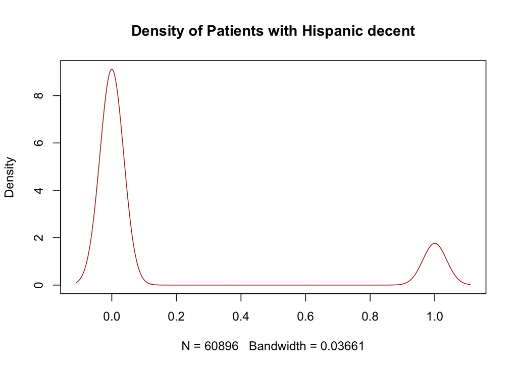

```r
plot(density(mammogram$hispanic), col="firebrick", main = "Density of Patients with Hispanic decent")
```

The bar plot below demonstrates that a significant amount of patients are white while very few of them are Native American or mixed race.

The barplot below demonstrates that a significant amount of patients are white while very few of them are Native American or mixed race.

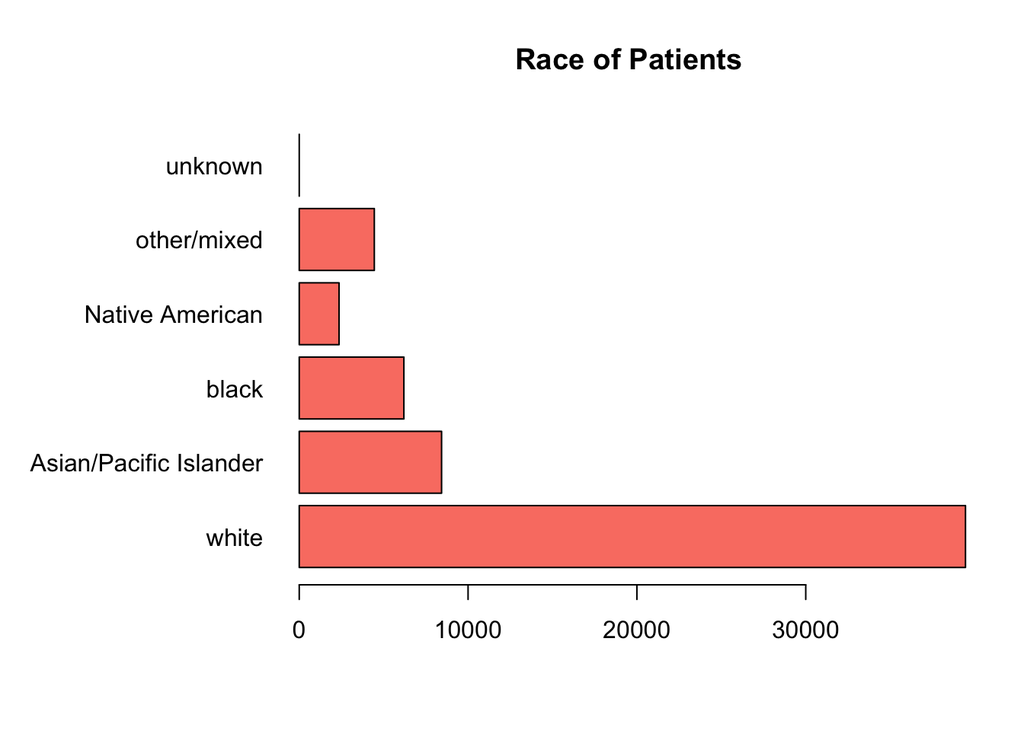

```r
par(mar=c(5, 10, 4, 2))
plot(mammogram$race, col="salmon", main="Race of Patients", horiz = TRUE, las=1)
```

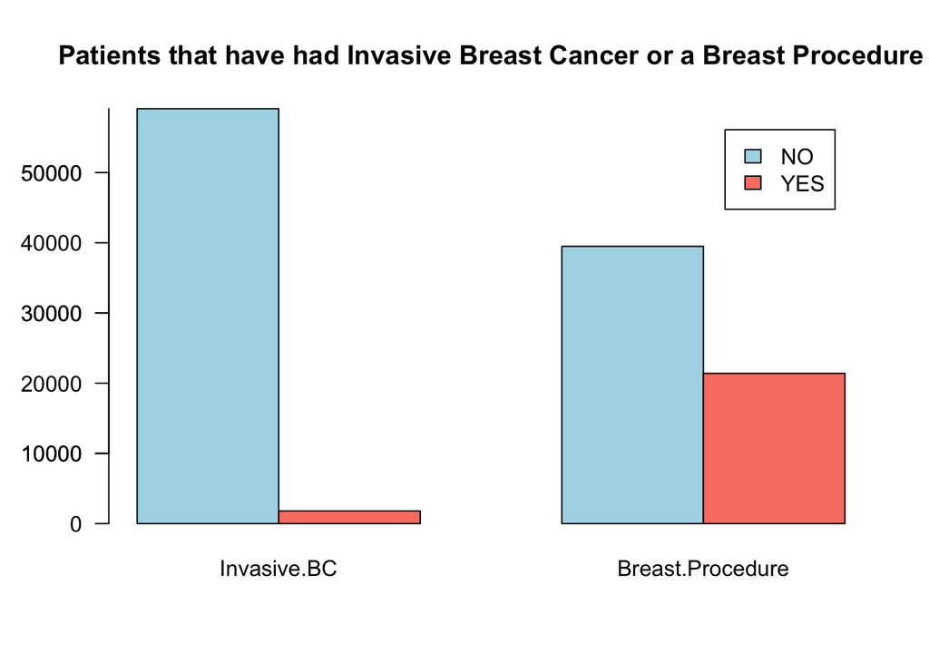

```r
# count number of yes and no of each table
Invasive.BC = table(mammogram$invasive.bc)
Breast.Procedure = table(mammogram$breast.procedure)

# plot both items side by side in same graph
barplot(cbind(Invasive.BC, Breast.Procedure), main="Patients that have had Invasive Breast Cancer or a Breast Procedure", beside=TRUE, col=c("lightblue", "salmon"), las=1)
ticks<-c(10000,30000,50000,70000)
axis(2,at=ticks,labels=ticks, las=1)
legend("topright", c("NO", "YES"), inset=0.05, fill=c("lightblue", "salmon"))
```

From this horizontal bar plot, some of the data might not be helpful when predicting because some of the breast density was measured differently and it does not provide helpful insight.

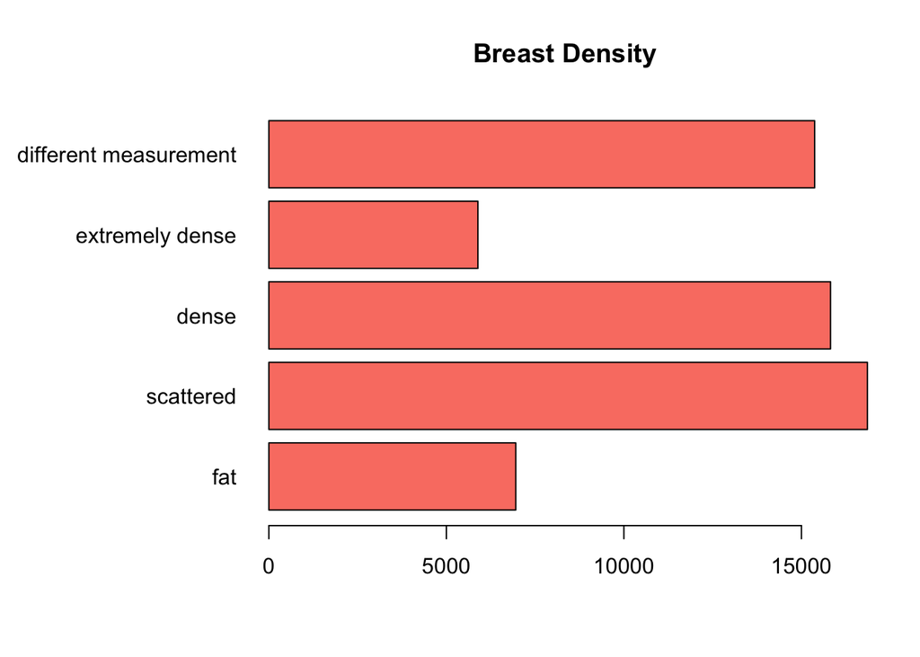

```r
par(mar=c(5, 10, 4, 2))
plot(mammogram$breast.density, col="salmon", main="Breast Density", horiz = TRUE, las=1)
```

From these two plots, the majority of the patients from the data do not have cancer. For those individuals that do have breast cancer, the age range that seems to be more prone to breast cancer are from 50 to 74 years of age.

From these two plots we can see that majority of the patients from the data do not have cancer. For those individuals that do have breast cancer the age range that seems to be more prone to breast cancer are from 50 to 74 years of age.

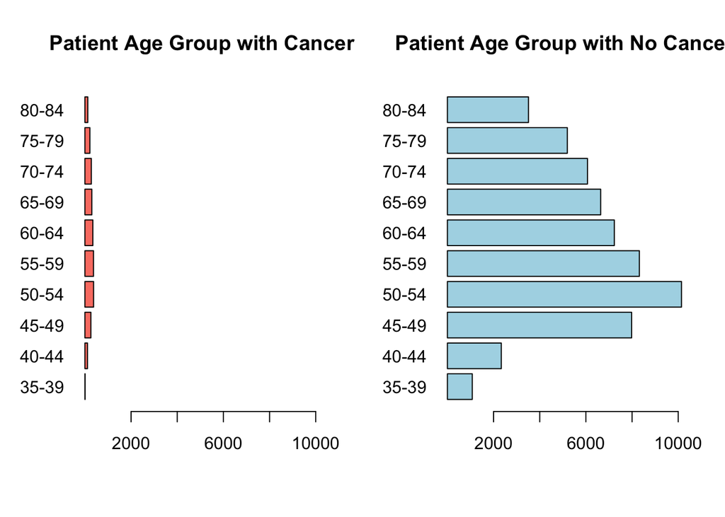

```r
# have two graphs side by side
par(mfrow=c(1,2))

# range to use for the x limit
range = sort(as.vector(table(mammogram$age.group[mammogram$cancer == 0])), decreasing = TRUE)[1]

# plot patients with cancer
barplot(table(mammogram$age.group[mammogram$cancer == 1]), main = "Patient Age Group with Cancer", col="salmon", xlim=c(1, range), horiz = TRUE,las=1)

# plot patients without cancer
barplot(table(mammogram$age.group[mammogram$cancer == 0]), main = "Patient Age Group with No Cancer", col="light blue", xlim =c(1, range), horiz = TRUE,las=1)
```

```r
par(mar=c(5, 10, 4, 2))
rows = sample(1:nrow(mammogram), floor(nrow(mammogram)/30))
plot(as.numeric(mammogram$age.first.birth[rows]), col=ifelse(mammogram$cancer==1, "red", ifelse(mammogram$cancer==0, "lightblue", "orange")), pch=20, yaxt="n", ann=FALSE)
axis(2, at=1:3, labels=c("Age < 30", "Age >= 30", "Nulliparous"), las=1)
legend(1500,1.5, c("Cancer", "No Cancer"),col=c("red", "lightblue"), cex = 0.67, pch = 19)
```

[figure not shown]

[figure not shown]

## Splitting data into training and testing datasets

In order to continue our work on predicting whether a patient has breast cancer or not, we will split the data into to testing and training dataset. That way we can train or models and test our results.

```r
mammogram$cancer = NULL
set.seed(132)
split = split_data(mammogram)
tr_dat = split[[1]]
te_dat = split[[2]]
```

## Creating Classification Tree

Creating a classification tree allows data to be organized into different nodes that can visually display predictions of the data.

## Model 1

This can make it easier to interpret whether the features we chose in our hypothesis helps predict if a patient is under risk of breast cancer.

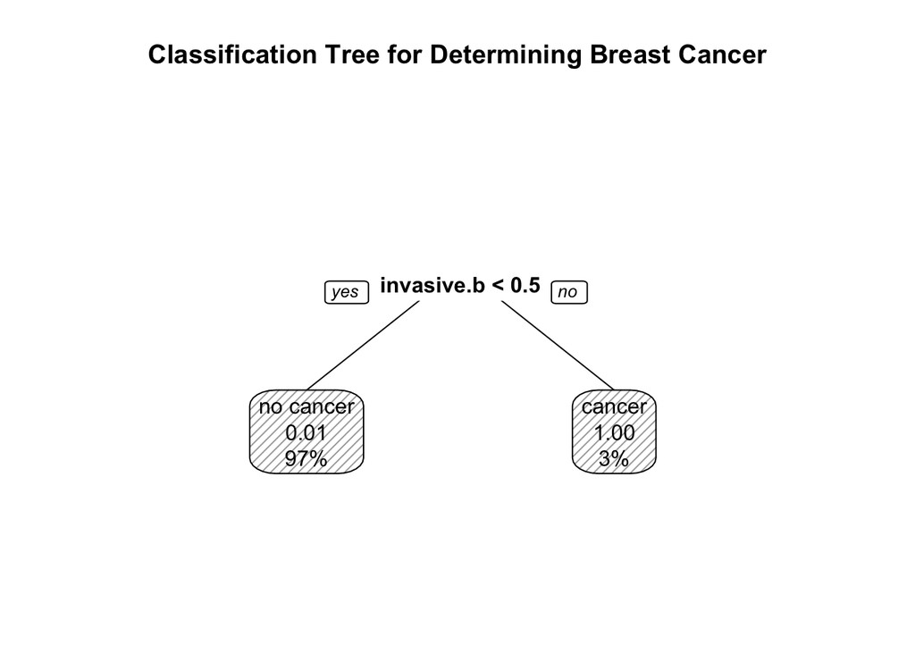

```r
fit = rpart(cancer_factor ~ age.group + breast.density + relatives.with.bc + invasive.bc + menopause, data = tr_dat, method="class")

prp(fit, extra=106, varlen=-10, main="Classification Tree for Determining Breast Cancer",box.col=c("palegreen")[fit$frame$val])
```

```r
#summary(fit)
```

## Analyzing Model 1

```r
predicted = predict(fit, newdata = te_dat, type="class")
actual = te_dat$cancer_factor

confusion_matrix = table(actual, predicted)
TN = confusion_matrix[1,1]
FN = confusion_matrix[2,1]
FP = confusion_matrix[1,2]
TP = confusion_matrix[2,2]

confusion_matrix
```

```
##            predicted
## actual      no cancer cancer
##   no cancer     14588      0
##   cancer          155    482
```

```r
accuracy = mean(predicted == actual)
round(accuracy, 3)
```

```
## [1] 0.99
```

Here we can see that this new model predicted recall more than seventy-five percent of the time.

```r
# precision = true positives / (true positives + false positives)
precision = TP/(TP+FP)

# recall =  true positives/ (true positives + false negatives)
recall = TP/(TP + FN)

paste("precision:", round(precision, 3))
```

```
## [1] "precision: 1"
```

```r
paste("recall:", round(recall, 3))
```

```
## [1] "recall: 0.757"
```

The data from the double density plot below illustrates how no breast cancer was predicted most of the time with a margin of error while the other prediction is completely accurate.

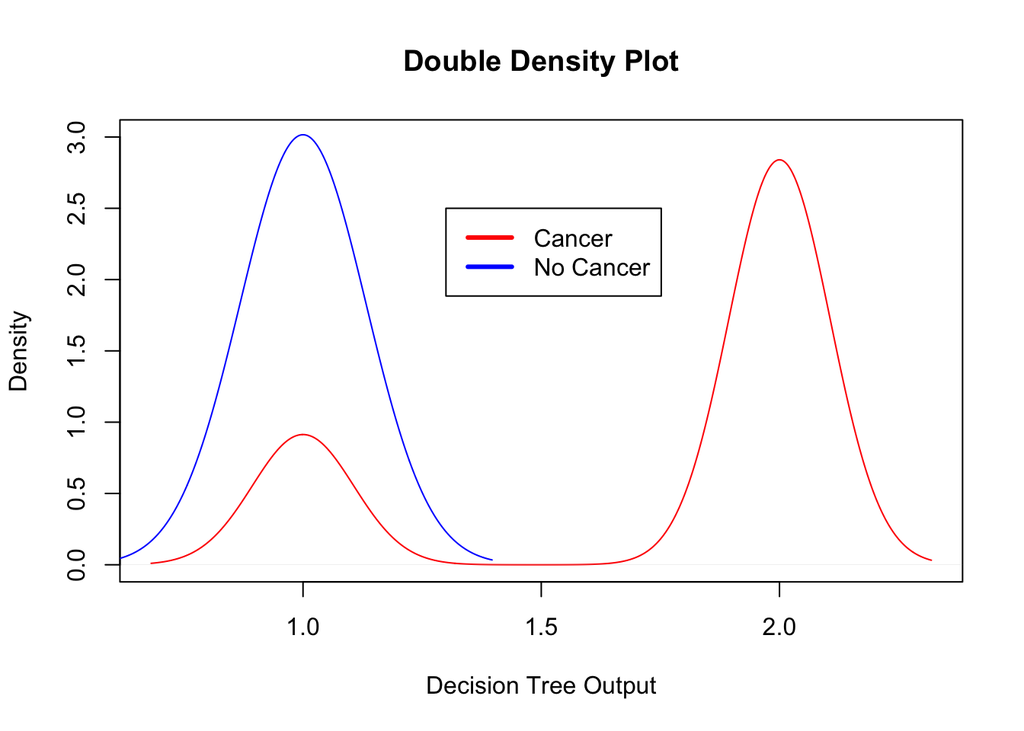

```r
plot(density(as.numeric(predicted[actual == "cancer"])), main = "Double Density Plot", xlab="Decision Tree Output", col="red", ylim=range(0:3))
lines(density(as.numeric(predicted[actual == "no cancer"])), col="blue")
legend(1.3,2.5, c("Cancer", "No Cancer"),col=c("red", "blue"), inset=0.05, lty=1, lwd=3)
```

Errors in both training data and testing data are calculated.

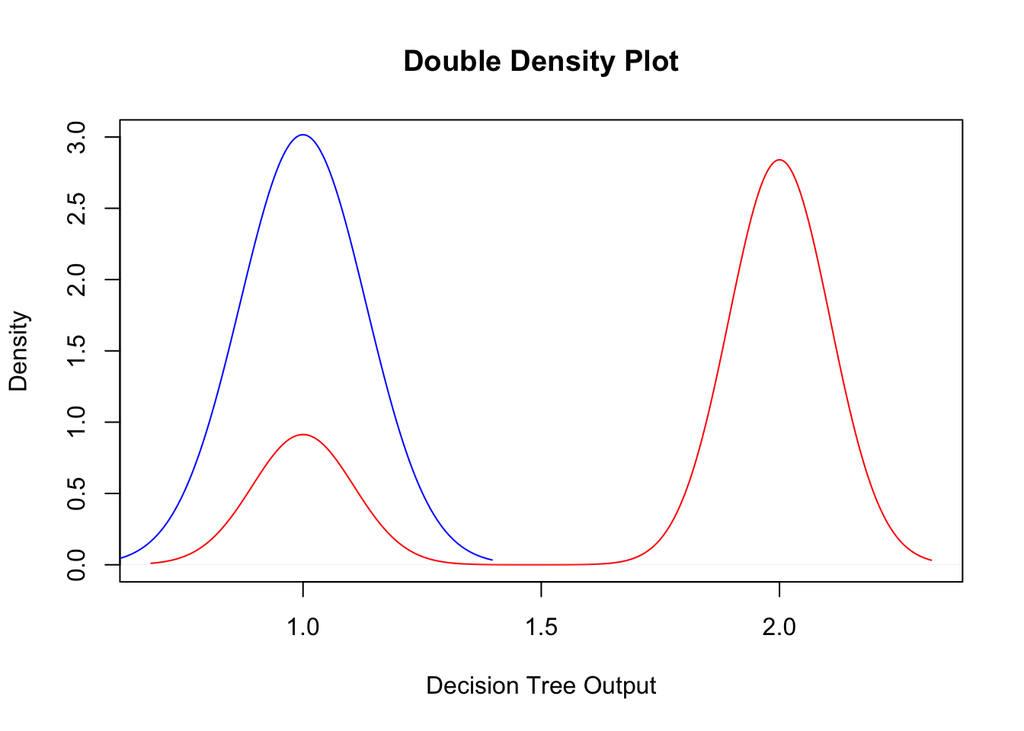

```r
plot(density(as.numeric(predicted[actual == "cancer"])), main = "Double Density Plot", xlab="Decision Tree Output", col="red", ylim=range(0:3))
lines(density(as.numeric(predicted[actual == "no cancer"])), col="blue")
```

Errors on both training data and testing data are calculated.

```r
te_errs = c()
tr_errs = c()
te_actual = te_dat$cancer_factor
tr_sizes = seq(100, nrow(tr_dat), length.out=10)
for (tr_size in tr_sizes) {
  tr_dat1 = tr_dat[1:tr_size,]
  tr_actual = tr_dat1$cancer_factor
  fit = rpart(cancer_factor ~ age.group + breast.density + relatives.with.bc + invasive.bc + menopause, data = tr_dat, method="class")

  # error on training set
  tr_predicted = predict(fit, newdata = tr_dat1, type="class")
  err = sum(tr_actual != tr_predicted)/length(tr_predicted)
  tr_errs = c(tr_errs, err)

  # error on test set
  te_predicted = predict(fit, newdata = te_dat, type="class")
  err = sum(te_actual != te_predicted)/length(te_predicted)
  te_errs = c(te_errs, err)
}
```

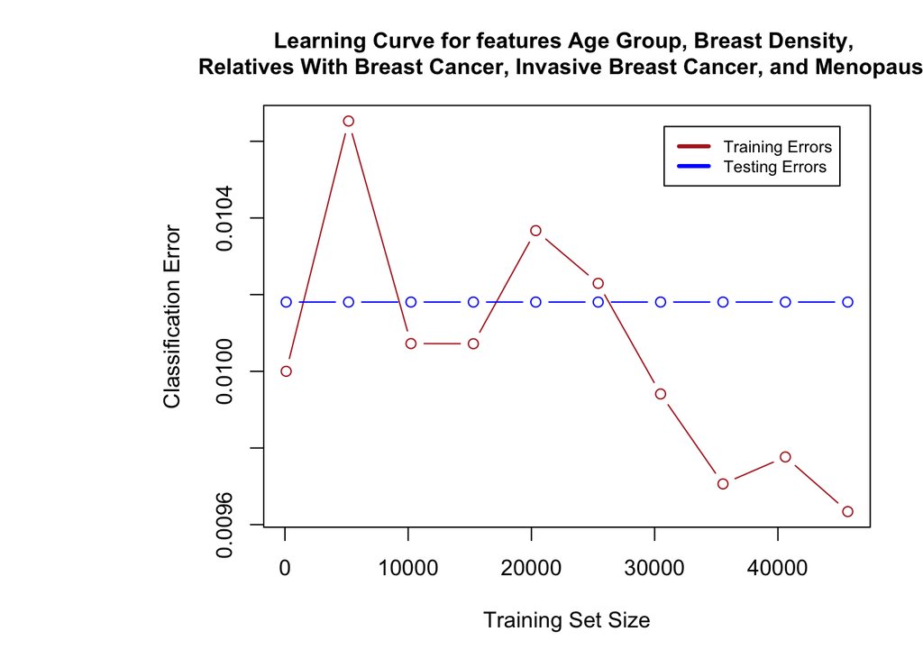

```r
par(mar=c(5, 10, 4, 2))
plot(tr_sizes, tr_errs, col="firebrick", type="b", ylim=range(c(te_errs,tr_errs)), ylab="Classification Error", xlab="Training Set Size", main=paste("Learning Curve for features Age Group, Breast Density,", "\nRelatives With Breast Cancer, Invasive Breast Cancer, and Menopause"), cex.main=1)
points(tr_sizes, te_errs, col="blue", type="b")
legend("topright", c("Training Errors", "Testing Errors"), inset=0.05, lty=1, lwd=3, col=c("firebrick", "blue"),cex = 0.75)
```

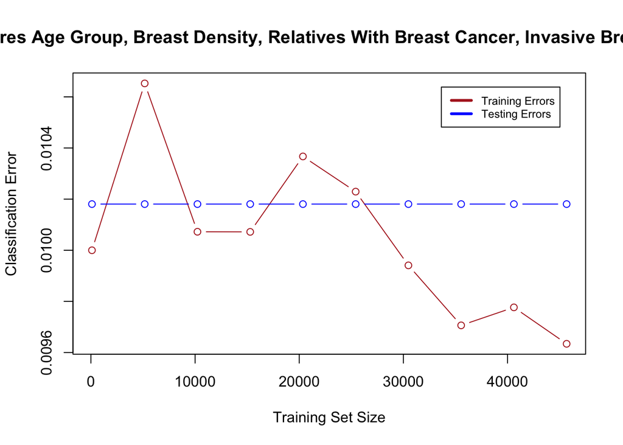

```r
plot(tr_sizes, tr_errs, col="firebrick", type="b", ylim=range(c(te_errs,tr_errs)), ylab="Classification Error", xlab="Training Set Size", main="Learning Curve for features Age Group, Breast Density, Relatives With Breast Cancer, Invasive Breast Cancer, and Menopause")
points(tr_sizes, te_errs, col="blue", type="b")
legend("topright", c("Training Errors", "Testing Errors"), inset=0.05, lty=1, lwd=3, col=c("firebrick", "blue"),cex = 0.75)
```

Another fit is produced without the invasive breast cancer feature. The tree below demonstrates that without taking invasive breast cancer into consideration for predicting breast cancer, no breast cancer is found in any patient.

```r
fit = rpart(cancer_factor ~ menopause + age.group  + breast.density + race + hispanic + age.first.birth + relatives.with.bc + breast.procedure + last.mammogram + surgical.menopause + hormone.therapy, data = tr_dat, method="class")

prp(fit, extra=106, varlen=-10, main="Classification Tree for Determining Breast Cancer")
```

[figure not shown]

## Analyzing Model 2